# Carnet de bord de l’ouverture des données de Nezel

par Elsa Ayache, Camille Buonanno, Loris Garrido, Solena Lefeuvre, Camille Maillet & Jodie Van de Riet

## Compte rendu | Jour 1

**9h-10h30**

Réunion de présentation

**10h30-12h**

**Prise en main du site internet** *Opendatacanva* et découverte des étapes

**Recherche sur la commune de Nézel** via le site internet (nombre d’habitants, localisation, organigramme de la mairie)

**Réflexion** sur le travail et répartition des tâches

**Premier contact** avec l’agent de mairie en contact avec nous cette semaine : le maire. Nous lui avons envoyé un e-mail pour proposer un premier rendez-vous

**Préparation de l’appel avec le maire :** préparation et répartition des questions à poser, réflexion sur les thématiques à aborder

ð Difficulté rencontrée : nous n’avions pas prévu de devoir, dès ce premier appel, demander au maire quelles données étaient disponibles et comment les récupérer étant donné que nous avions très peu de connaissances du fonctionnement de la commune à ce moment là

**13h-18h**

Appel avec le maire : nous lui avons posé les questions prévues sur *opendatacanva* et nous avons abordé avec lui les thématiques qui pourrait intéresser sa commune, nous avons tenté d’identifier ses besoins, les problèmes que rencontrent la commune etc.

Nous avons constaté que la très petite taille de la commune (1040 habitants) allait constituer l’une des principales difficultés. La mairie dispose de très peu d’agents qui sont très occupés, et quelques bénévoles (aussi très occupés) aident la mairie dans ses tâches. Le principal objectif du maire est de faire en sorte que les jeunes restent, ou viennent s’installer, notamment des familles avec enfants. Nous avons aussi constaté qu’il n’y avait pas de lieu en lien avec le domaine de la culture à proprement parler (bibliothèque, musées, monuments classés). La ville est traversée par une autoroute, ce qui constitue son principal problème. Le maire nous a expliqué qu’il était très occupé, nous avons donc pris des rendez-vous avec lui pour tous les jours de la semaine. *Mardi : 10h30 - Mercredi : 17h - Jeudi : 17h - Vendredi : 14h*

ð **Difficulté n°1** : problèmes de connexion du maire sur *Gather* à nous avons terminé le rendez-vous par téléphone

ð **Difficulté n°2** : le maire ne nous a pas répondu à notre premier e-mail, nous avons donc fait part de notre difficulté aux *datactivistes*, qui nous ont finalement mis en relation avec lui directement sur *Gather*. Nous n’étions pas prêts étant donné que nous avions convenu avec les *datactivistes* que nous serions prévenus. Le début de l’appel manquait donc de professionnalisme.

ð **Difficulté n°3** : nous n’avions pas les informations concernant le déroulé du reste de la semaine, nous ne savions pas à quels moments nous aurions besoin de contacter le maire. Nous avons donc été contraints de prendre des rendez-vous avec lui sans savoir quand nous avions besoin d’effectuer ces rendez-vous car il nous a dit être très occupé et ne pas avoir le choix.

ð **Difficulté n° 4** : Le maire a peu de temps à nous accorder, aucun agent de la mairie n’a du temps non plus. Personne, à part l’intérêt personnel du maire, ne travaille sur les thématiques de *l’opendata*.

**Réunion** : nous avons revu ensemble les informations données par le maire et partagé notre ressenti sur cet appel et pour la suite.

**Filtrage et évaluation des informations collectées**

Nous avons filtré les données et constaté que la commune avait un score de **14**, et se situait au **palier 2.**

*Wishlist*

Nous avons sélectionné les 10 thèmes pour la réalisation de la *Wishlist* selon les besoins de la commune que nous avions identifiés avec le maire, et selon les possibilités que nous accordait notre palier. ð Difficulté rencontrée : la maturité de la commune n’est pas suffisante pour que nous puissions mobiliser les données liées aux commerces. La commune étant très petite, beaucoup de possibilités ne s’adaptent pas à Nézel ce qui contraint notre travail.

**Nous avons sélectionné les 10 thèmes suivants :**

- Actes d’état-civil
- Établissement d’accueil petite enfance
- Espaces verts
- Base horaire des administrations
- Equipements collectifs publics
- Lieux de covoiturage
- Îlots de fraîcheurs - équipements
- Lieux de stationnement hors voiries
- Budget primitif
- Parking à vélos

**Retour envoyé au maire** : Nous avons envoyé un e-mail au maire pour le remercier pour cet appel, et pour l’informer des thèmes que nous souhaitons mobiliser pour l’introduction de l’*opendata* dans sa commune. Nous en avons aussi profité pour le prévenir que nous aurions besoin de ces données afin qu’il soit prêt à nous indiquer comment les obtenir lors de notre rendez-vous téléphonique de demain matin.

**Préparation pour mardi** : Nous avons préparé la journée de demain en prenant connaissance des étapes prévues pour demain sur le site *opendatacanva.*

**Bilan :**

Nézel est une ville de 1040 habitants située dans les Yvelines, près de Mantes-la-Jolie. La mairie ne dispose d’aucun service et de très peu d’agents. Elle dépend beaucoup de la communauté urbaine. Le maire est très intéressé par l’_opendata _mais dispose de peu de moyens et de très peu de temps pour mettre en œuvre les actions en ce sens. La ville est traversée par une autoroute ce qui est aujourd’hui très gênant pour les habitants, la ville se retrouve coupée en deux . La mairie communique _via _son site internet et _via _Facebook grâce à des bénévoles. Les comptes rendus des délibérations du conseil municipal sont rendus publics sur le site internet et dans la mairie.

Le maire est plutôt intéressé par les thématiques environnementales, les dispostifis liés à la politique de la famille, et les transports. Il perçoit l’opendata comme un moyen d’identifier les besoins et les problèmes, ce qui permettra la mise en oeuvre de services publics pertinents. L’objectif principal du maire est de convaincre les jeunes de rester vivre à Nézel, et d’en attirer de nouveaux.

## JOUR 2 – IDENTIFICATION

**9h30-9h45** **Point avec Arthur**

Nous avons récapitulé notre situation en anticipation de notre appel avec Monsieur le Maire à qui nous allons demander :

- La pertinence de la wishlist
- Les moyens d’obtenir les données correspondant à chaque thème de la wishlist

**10h-10h30**

Répartition des rôles lors de l’appel et des demandes spécifiques à faire à Monsieur le Maire

**10h40- 11h30**

**Appel téléphonique avec Monsieur le Maire** Discussion autour de chaque point de la wishlist afin d’évaluer la pertinence des thèmes et l’obtention des données

ð **Difficulté n°1** : Il n’existe aujourd’hui aucune donnée Excel en mairie pour la totalité des catégories demandées que nous avions sélectionner

ð **Difficulté n°2** : Aucun des services que nous avons contracté n’a pu nous transmettre des informations ou ne nous a répondu

ð **Difficulté n°3** : L’agent qui s’occupe des espaces verts n’a pas d’ordinateur

**11h30- 11h30**

**Appel avec Arthur**

Suite à cet appel, nous avons fait part à Arthur de nos difficultés afin de nos difficultés pour collecter les données et poursuivre les tâches 2.2, 2.3 et 2.4.

**12h-12h30**

Répartition des rôles pour tenter de contacter les différents interlocuteurs dans le but de collecter les données

**Appel** Madame Voinier afin d’obtenir les données à propos des actes d’État-Civil

ð **Difficulté n°4** : Madame Voinier ne peut nous donner ces données que jeudi, ce qui nous empêche d’avancer dans ce domaine

- **Recherche** des données à propos des îlots de fraîcheur mais aucun donnée exploitable n’a été transmise ou trouvée
- **Recherche** des données à propos de la base horaire des administrations (recherches et appel)
- **Recherche** des données à propos des budgets primitifs (recherches et appel)
- **Recherche** des données données à propos des lieux de covoiturage et lieux de stationnements hors voiries (recherches et appel de la communauté urbaine)

**13h-17h**

Aucun de nos interlocuteurs ne peut nous fournir des données excel à traiter

Nous changeons donc de stratégie et décidons de réaliser nous mêmes les bases de données à partir d’information trouvée sur le Web en les confirmant par téléphone avec :

- La directrice de la crèche Pomme d’Api
- Le personnel de la mairie

Modification ainsi la Mindmund transmise ci-dessous puisqu’aucune de nos sources ne peut nous servir.

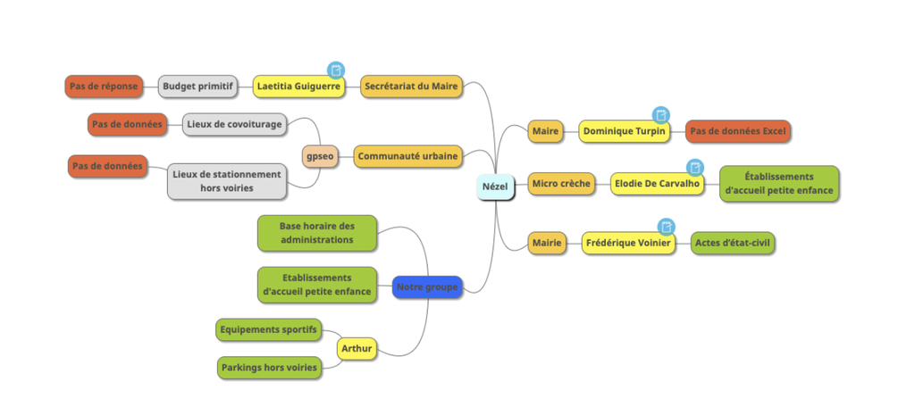

Nous faisons part de nos problématiques à Arthur qui nous aide à obtenir une troisième base de données grâce à l’open data d’ « opendatastreet »

Nous réalisons en commun le nettoyage des données récupérées (étape 2.3)

Nous effectuons un bilan des données que nous possédons et de la manière dont allons les valoriser auprès de la commune

Nous réalisons en commun la wanted wishlist (étape 2.4)

[figure not shown]

Nous ajoutons une ligne « 0. Base de données “diverses” créée à partir de OpenstreetMap avec Arthur».

Dans notre évaluation de la wishlist nous conservons donc cette nouvelle database fournie par Arthur, les données relatives aux établissements de la petite enfance et celles relatives à la base horaires des administrations car ce sont les seuls jeux de données complets que nous possédons.

**Préparation pour mercredi** : Nous avons préparé la journée de demain en prenant connaissance des étapes prévues pour demain sur le site *opendatacanva.*

**Productions :**

- Mind Mup: https://app.mindmup.com/map/_free/2021/02/e9ab27b0710711ebb9088dfef5589667
- Wanted Wishlist: https://drive.google.com/file/d/1T0Mb1x3f7wfQUSLCoaFIQaFbyALi0Le1/view

**Bilan** : Face à l’impossibilité de récupérer des données fournies directement par les services de la mairie ou de la communauté urbaine nous avons cherché nous-même des données à traiter. Grâce à l’aide d’Arthur et nos recherches nous avons pu réaliser les étapes du jour. Notre nombre de base de données restent néanmoins limité.

## **JOUR 3 – MISE EN QUALITE**

**9h00- 9h30:**

**Réunion avec Arthur**

Arthur nous présente les étapes de la journée.

**10h:**

Nous évaluons le travail de mise en qualité du jeu de données de l’Acte d’état-civil envoyé hier soir par Madame Voinier (étape 2.3). Nous mettons à jour la WishList suite à la réception du document.

[figure not shown]

Nous appelons Madame Voinier qui nous redirige vers Madame Giguerre afin d’obtenir des données manquantes pour le jeu de données “Établissements d’accueil petite enfance” (horaires d’ouverture et capacité d’accueil de la maternelle)

ð **Difficulté n°1:** L’école ne peut pas nous donner les informations directement car nous sommes en période de vacances scolaires donc elle est fermée.

**10h30:**

Nous regardons les vidéos de la journée pour nous les remémorer, et faisons un point d’équipe pour nous répartir les tâches. Nous avons pour objectif d’obtenir autant de jeux de données valides que possible au terme de la journée. Nous commençons alors la mise en qualité des données.

**Nettoyage**

Nous n’avons pas vraiment eu de nettoyage des données à effectuer dans la mesure où nous avons créé nous mêmes la plupart des jeux de données. En effet, la commune de Nézel ne nous a pas fourni de fichiers Excel à l’exception des Actes d’état civil au terme de la deuxième journée. Ainsi, pour le premier pas, nous n’avons pas eu de colonnes ou cellules vides à supprimer. Nous vérifions qu’il n’y a pas de fautes de frappe ou de valeurs erronées dans les jeux de données.

**Compilation**

De même, ayant créé les fichiers, nous n’avons pas eu à les compiler, à l’exception du jeu de données “Actes d’état civil” car il n’y avait pas assez d’informations. Par exemple, les dates des événements et leur nombre n’étaient pas renseignés. Nous avons donc décidé de faire la somme des naissances et celle des décès.

ð **Difficulté n°2:** Presque aucun de nos jeux de données nous a été envoyé par la commune de Nézel. Nous les avons créés et ils ne contiennent pas beaucoup de cellules ce qui implique qu’il y a assez peu de travail de nettoyage ou de compilation à faire

**11h00 :**

**Standardisation**

Nous commençons le travail de standardisation des jeux de données mais rencontrons des problèmes. Nous écrivons nos questions et prévoyons un appel avec Arthur.

**13h45- 14h00:**

**Appel avec Arthur**

Nous posons les questions suivantes :

- Existe-t-il un format spécial pour écrire un horaire qui concerne uniquement les mercredis et les vacances?
- Comment trouver une géolocalisation ?
- Comment trouver l’ID ?
- Comment trouver les codes des équipements?
- Pourquoi n’y a t-il pas d’exemple du template Lieux de stationnement ?

  Arthur répond à nos questions. Il ressort de cet appel que nous ne pouvons pas trouver l’ID et les codes d’équipement car Nézel ne nous a pas donné ces informations et nous ne pouvons pas les trouver.

**14h30:** Nous faisons un point de groupe pour nous répartir les tâches suite à l’appel et nouscomplétons les données du fichier Équipements.

**Standardisation**

Nous** **poursuivons le travail de standardisation. Nous nous référons aux onglets “exemples” pour nous adapter aux conventions d’écriture, et effectuons quelques modifications sur WorkBench. Nous renommons des colonnes selon les standards, et vérifions que les valeurs y correspondent.

ð **Difficulté n°3:** Le template Lieux de stationnement ayant été supprimé, nous devons utiliser l’exemple sur le template d’Epône

Nous disposons désormais de jeux de données standardisés selon les schémas. Nous pouvons commencer l’étape de la validation.

**Validation**

Nous regardons si un validateur existe pour nos jeux de données. Il n’en existe que pour deux : “Équipements sportifs” et “Lieux de stationnement”.

Equipements sportifs : le jeu de données est invalidé car il manque le code d’identification des équipements (ID)

Lieux de stationnement : Invalidé car validata indique qu’il manque trop de données.

ð **Difficulté n°4:** Nous pensions que ces deux jeux de données seraient validés car nous les avons créés avec Arthur.

Nous vérifions manuellement les schémas qui ne disposent pas de validateurs. Après avoir comparé l’agencement et le nom des colonnes avec les modèles sur Workbench, nous contrôlons aléatoirement les colonnes.

ð **Difficulté n°5:** Certains jeux de données comme Actes d’État civil comportent moins de 5 cellules par colonnes donc le contrôle aléatoire est inutile.

**17h00: Appel avec le maire de Nézel**

Nous lui avons présenté les thématiques des trois jeux de données retenus. Nous lui avons également demandé ses identifiants data.gouv.fr car nous avons vu que deux jeux de données y sont publiés pour Nézel. Le maire ne les a pas actuellement mais va les demander à son Conseiller en charge du numérique.Nous lui envoyons un mail avec les jeux de données validés.

**Bilan :**

❌ Les jeux de données “Équipements sportifs” et “Lieux de stationnement” sont invalidés car il manque des données selon Validata

✅ Les jeux de données “Base horaires des administrations”, “Actes d’état-civil”, et “Établissements d’accueil petite enfance” ont une structure qui correspond au modèle après vérification manuelle.

Base horaires des administrations :

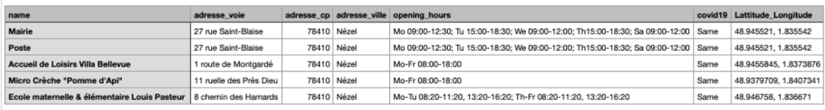

Actes d’état-civil :

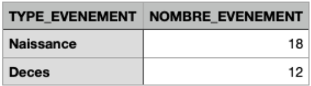

Établissements d’accueil petite enfance :

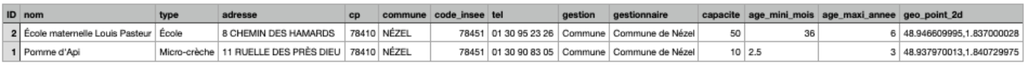

## **JOUR 4 – PUBLICATION**

**9h00- 9h30: Briefing avec Arthur**

Arthur nous présente les étapes de la journée : publication et stratégie de communication.

ð **Difficulté n°1:** nous pensions publier sur opendatagouv, lors de notre appel avec le Maire nous lui avions demandé les codes d’accès, finalement la publication se fait sur opendatasoft avec les autres communes du GPSEO.

**9h30: Retour sur nos jeux de données validés**

ð **Difficulté n°2:** Nous remarquons une coquille dans un de nos templates “base horaires administration” avec l’oubli de la mention des horaires de vacances scolaires pour le centre de loisirs. Nous mettons donc à jour notre template.

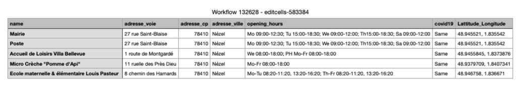

ð **Difficulté n°3:** Lors du briefing, Arthur nous a notifié que nous pouvions valider à partir d’un seuil de 80%. Nous faisons donc repasser le test Validata sur les deux jeux de données non-validées la veille. Nous ne pouvons même pas avoir de score car il manque la colonne ID dans le template lieux de stationnement.

**10h00: Fiches descriptives**

Pour nos trois jeux de données validés :

- base horaires administrations
- établissements d’accueil petite enfance
- actes d’état civil

Nous réalisons les fiches descriptives pour chaque template de jeux de données.

https://docs.google.com/presentation/d/1tOYPkM5ijTgkeo4AdGkaLh2WQLiOXVZ1SEsuOs28FoI/edit#slide=id.g49a98fd62f_0_196

ð **Difficulté n°4:** Afin de s’assurer de la fréquence des mises à jour pour les actes d’état civil, ainsi que pour les informations sur l’école maternelle/élémentaire, nous décidons de contacter Madame Voinier pour vérifier nos intuitions. Cependant, la mairie de Nézel n’est ouverte que le jeudi après-midi.

Nous nous concertons et décidons de prévoir une mise à jour annuelle de l’état civil et pour les écoles (mais sur l’année scolaire dans ce cas).

**11h00: Stratégie de communication**

Nous prenons connaissance collectivement du template prévoyant la stratégie de communication.

Nous comprenons rapidement que notre stratégie de communication externe sera essentiellement liée aux canaux de communication de la commune (site internet et Facebook). Concernant la stratégie de communication interne, nous pensons fonctionner par mail afin de mettre au courant les la dizaine d’agents municipaux qui ne sont pas réunis quotidiennement, en fonction de leur fonction.

**11h30 - 12h00 : Appel avec Arthur**

Nous abordons quelques questions, notamment liées à nos échecs de validations de deux autres jeux de données. Même avec l’ajout de la colonne ID avec Arthur, le template n’est pas validé. Même problème pour les établissements sportifs et de loisirs avec l’absence de numéro SIRET (introuvable).

Nous clarifions ce qui est attendu de nous, nous nous approprions donc le template avec les spécificités de la commune de Nézel afin d’adapter, au mieux, la stratégie de communication.

Étant donné que nous avons terminé les étapes de fiches descriptives, et que nous ne publions pas sur opendatagouv, Arthur nous forme et nous montre la méthode pour publier sur opendatasoft.

La publication des données, liée à la communauté urbaine du Grand Paris Seine et Oise, nous donne l’idée, afin de donner plus de visibilité à la publication des données de la commune de Nézel, de demander à la CU de publier également les articles d’informations.

ð **Difficulté n°5:** La publication des données par la CU ne sera pas alignée à notre temporalité du Challenge Data. Nous allons donc orienter la stratégie de communication, seulement sur la commune. (Difficultée amplifiée, voir Difficulté n°8)

**12h00: Publication de nos jeux de données**

Suite au tutoriel lors de l’appel, nous nous mettons à la publication sur opendatasoft. La prise en main est relativement simple, et nous publions avec succès nos 3 jeux de données.

La seule interrogation relative à la publication concernait l’identité du producteur de données. Arthur, en contact avec le représentant du GPSEO, nous confirme que le producteur est la Commune de Nézel afin d’assurer la bonne publication.

URLs workbenchdata :

- base horaires administrations : https://app.workbenchdata.com/workflows/132628
- accueil petite enfance : https://app.workbenchdata.com/workflows/132606
- actes d’état civil : https://app.workbenchdata.com/workflows/132902

ð **Difficulté n°6:** La publication des résultats sur opendatasoft a l’air de se faire sur le compte de la CU de Grand Paris Seine et Oise, hors ils n’ont pas été nos interlocuteurs, ou très peu. Nous ne savons pas vraiment qui va alimenter et entretenir ce compte et la publication des données, notamment si Nézel décide de continuer son ouverture à l’open data. Nous n’arrivons pas à cerner la place de la commune au sein de ce processus. (Doute confirmé, voir difficulté n°8)

**14h00**: **Réunion avec Hélène et Mayara**

ð **Difficulté n°7:** Une réunion à 14h était prévue dans la salle de réunion bleue. Une partie de notre groupe s’y est rendue et une deuxième est restée à la table afin de continuer la stratégie de communication. Nous avons été surpris de voir les experts datactivistes accompagnés d’Hélène et Mayara, sans aucune information sur leur rôle et la raison de leur présence. Ce moment d’incompréhension nous a perturbé dans la présentation que nous avions, qui concernait les visualisations que nous allons devoir faire demain.

Nous avons pris des notes sur les méthodes de visualisations des données sur opendatasoft afin de nous préparer aux réalisations du lendemain.

**14:30 - 15:00: Réalisation du plan de communication**

Adaptation du template du plan de communication à la réalité de la commune de Nézel, objectifs et activités programmées. Projet de suite adapté à la petite taille de la commune de Nézel, nous conseillons de privilégier la coopération avec les communes voisines participantes au challenge data.

**15:00:** **Réunion avec Arthur**

La réunion nous a permis d’aborder nos interrogations :

- point sur les datavisualisations prévues pour demain : données peu nombreuses, nous nous posions la question des datavisualisations les plus pertinentes
  - cartes pour la base horaires administration et établissements d’accueil petite enfance
  - étude démographique potentielle pour actes d’état civil, potentielle comparaison avec les villes communes
- point sur la réalisation concrète du plan de communication
- questions sur le déroulé de la journée de demain, et notamment au sujet du moment de restitution
- proposition de partage de templates vides de bases de données pour aider la commune de Nézel à mieux collecter les données afin d’améliorer leur politique d’open data

**15:00 - 16:30: Finalisation de la stratégie de communication**

Après concertation collective, nous décidons de nous répartir le travail pour finaliser cette partie.

- rédaction de l’article d’informations pour le site web et Facebook de la commune
- rédaction du communiqué de presse
- rédaction d’un email à visée interne
- réappropriation des templates vides des catégories de la wishlist pour lesquelles les données étaient introuvables dans la commune : espaces verts, équipements collectifs publics, lieux de covoiturage, îlots de fraîcheurs - équipements, lieux de stationnement hors voiries, budget primitif

En ce qui concerne l’ “après” challenge data, pour la commune de Nézel, nous avons voulu donner les outils les plus adaptés à cette commune de 1040 habitants. Avec seulement une dizaine d’agents municipaux, Nézel n’est pas concernée par les obligations de politique d’open data et fait preuve d’un enthousiasme et d’une politique volontariste. Avec les données que nous avons pu récolter (peu), nous avons essayé de répondre aux objectifs de valorisation du territoire et d’informations aux habitants. Alors pour le futur de l’open data à Nézel, nous avons décidé d’orienter surtout sur une meilleure collecte de données (templates vides).

- URL plan de communication : https://drive.google.com/file/d/169emQmd4bewInhEg-dUS-XwOtbsLwfWc/view?usp=sharing

**17:00: Appel avec le maire + mail**

Nous abordons avec le maire tous les points de la journée : la publication, la stratégie de communication.

Nous communiquons par mail avec les templates vides, les données publiées en format excel, l’article d’informations, le communiqué de presse et le modèle de mail interne.

Nous présentons au maire le forum pour la restitution de demain qui semble satisfait de notre travail.

ð **Difficulté n°8:** La question de la validation des données, avant la publication, par la CU pose problème. Concernant les informations, comme l’état civil, relevant de la compétence municipale, le maire souhaiterait valider de son côté également.

## JOUR 5 – VALORISATION

**9h30 - 10h00** : Réunion avec Arthur.

Nous avons appris que nos données seront finalement publiées sur Opendatasoft mais également surdatagouv.fr. Arthur nous a également présenté le programme de la journée.

**10h - 10h30** : Réunion avec Étienne.

Étienne nous a présenté différents outils disponibles sur Opendatasoft.

Notamment la possibilité de faire une carte qui combine deux jeux de données, et comment modifier ses caractéristiques (couleurs, formes des puces,…).

Il nous a également présenté les possibilités relatives aux graphiques sur Opendatasoft.

**10h30 - 12h** : **Réalisation de datavisualisations avec les données publiées.**

Nous avons regardé les tutoriels et les activités à réaliser pour la journée.

Au regard de nos jeux de données limités, nous avons décidé de créer un support visuel pour chacun.

Les bases de données _base horaires administration _et _petite enfance _ne prêtent pas à des graphiques, mais à des cartes, que nous souhaitons réaliser directement sur Opendatasoft au regard des tutoriels dont nous avons bénéficié.

Pour le jeu de données *actes d’état civil,* nous souhaitons réaliser un diagramme en bâtons présentant le nombre de naissances et de décès, afin de rendre compte du taux de natalité positif de la commune. Pour le rendre plus pertinent, nous voulons le comparer à celui d’une autre commune de taille similaire.

À ce stade nous avions estimé 3 datavisualisations pertinentes pour nos jeux de données :

- une page présentant les horaires des administrations, répertoriées sur une carte ;
- une carte combinant le jeu de données _base horaires administrations _avec celui sur la *petite enfance* ;
- un diagramme en bâtons pour le jeu de données *actes d’état civil*.

Nous avons donc finalisé la première datavisualisation commencée la veille, débutée la veille à la suite d’une réunion avec Mayara. Elle nous avait présenté les étapes de création d’une page de présentation personnalisée avec une carte pour notre jeu de données *base horaires administrations*. Elle nous avait ainsi présenté le code html et css et les parties à modifier afin de créer cette page. C’est pourquoi nous avons modifié quelques lignes du code (L27 pour modifier l’image, L281 pour la couleur notamment) pour qu’elle soit visuellement agréable et ludique à utiliser.

Ensuite, nous avons réalisé un diagramme en béton permettant d’observer visuellement le nombre de naissances par rapport au nombre de morts cette année à Nézel, en utilisant la fonction analyse d’Opendatasoft.

❌ **Difficulté** : Nous voulions comparer ces données avec celles d’une autre commune de taille similaire (Épône par exemple), mais malheureusement aucun jeu de données ne permettait cette mise en comparaison. En d’autres termes, il n’était pas possible de croiser les jeux de données car il n’y a pas de jeux de données accessibles similaires sur Opendatasoft.

Enfin, nous avons réalisé une carte combinant le jeu de données *base horaires administrations* et *petite enfance*. Nous avons modifié les couleurs en respectant celles utilisées par la ville de Nézel sur son site internet, ainsi que les icônes sur la carte pour différencier les administrations des lieux de petite enfance. Nous avons décidé d’appeler cette visualisation *Lieux d’accueil à Nézel*.

Il est donc pratique pour les citoyens d’avoir sur une même carte les horaires de tous ces lieux publics.

**12h** : Réunion avec Étienne.

Étienne a validé nos datavisualisations, et nous a donné des pistes de réflexions pour ajouter des données sur notre carte, grâce à la base de données d’Opendatasoft.

❌ **Difficulté** : Nous n’avons malheureusement pas trouvé de données supplémentaires sur la commune de Nézel sur la base de données d’Opendatasoft… Nous avons voulu rajouter des données d’Openstreetmap mais aucune donnée n’était pertinente pour venir compléter notre cartographie.

**12h30** : Discussion avec Arthur.

Arthur nous a demandé les identifiants du compte opendata.gouv de la commune afin de publier les données. Nous avons donc envoyé un mail au Maire et essayé de l’appeler.

❌ **Difficulté** : Pas de réponse de la part du Maire, ni par mail ni par téléphone. **13h - 14h** : Pause déjeuner.

**14h - 15h** : **Contextualisation des datavisualisations réalisées.**

Nous avons rempli pour chaque jeu de données une fiche de *contexte de la visualisation*, en nous mettant dans la peau d’un agent de la collectivité, pour essayer de rendre compte de la pertinence de nos choix.

LIEN FICHES CONTEXTE :https://docs.google.com/document/d/1sAs3UsqQkT1-pm8iaQWceWtQ8rQC_Zh9K6s5HXjPj44/edit

**15h - 16h** : **Publication des datavisualisations.**

Nous avons généré les URL de nos datavisualisations conformément à la méthode décrite.

❌ **Difficulté** : Nous avons également reçu la réponse du Maire pour les codes du comptedata.gouv.fr de la commune de Nézel, nous informant qu’il ne les avait pas.

**16h** : Réunion avec Adrien.

Vérification de nos datavisualisations et de nos fiches *contexte.*

Tout est validé par Adrien pour publier une page pour Nézel sur Opendatasoft dans la rubrique commune, ouverte par le GPSEO.

**Adrien a réuni sur une page nos datavisualisations** : la page permet de réunir toutes nos datavisualisations ainsi que nos jeux de données.

**16h - 17h** : Bilan de la semaine.

Nous avons fait une restitution entre nous de notre semaine : nos réalisations, leur contribution pour la commune de Nézel, et surtout notre volonté de donner des outils au Maire afin de continuer cette démarche dans sa ville (notamment avec l’envoi des templates vides pour qu’il puisse récolter des données dans sa commune).

**17h - 18h** : **Forum de restitution**.

Nous avons tout d’abord échangé avec le Maire de Nézel, pour faire avec lui le bilan de cette semaine. Nous lui avons ainsi montré (en partageant notre écran) toutes nos datavisualisations, ainsi que nos recommandations dans le plan de communication (puisqu’il n’avait pas eu le temps de lire).

Nous avons ensuite pu discuter avec Madame Bernard (représentante de l’Incubateur des Territoires). Cet échange nous a permis de parler de notre expérience auprès d’une petite commune, et de questionner la place de l’égalité entre les petites communes comme Nézel face à des grandes villes disposant d’une politique d’open data d’une grande ampleur avec des agents spécialisés s’en chargeant.

## CONCLUSION

À la fin de cette semaine de traitement et d’analyse des données, nous dressons un bilan positif et encourageant du recours à l’open data dans la commune de Nézel. Petite commune des Yvelines, Nézel n’avait jamais interagi avec les données avant notre arrivée. Notre intervention a permis à la commune d’adopter l’open data afin de faciliter la vie de ses habitants et valoriser son territoire.

Au terme de ces cinq jours, nous avons permis l’ouverture de trois jeux de données : la base horaires des administrations publiques, les établissements d’accueil de la petite enfance et les actes d’état-civil de la commune. Ces trois jeux révèlent le peu d’informations dont nous avons disposées et le manque de *data* exploitables. Ce manque d’informations s’est avéré être notre principal frein à l’ouverture et au développement des données. Aussi, notre action s’est vue contrainte par la maturité de la commune sur ce sujet. Nous n’avons pu par exemple mobiliser les *data* liées au commerce. Sur ces points, les experts datactivists, surtout Arthur notre interlocuteur privilégié, ont été compréhensifs et nous ont aidé à réfléchir à des nouvelles pistes de réflexions plus adaptées à la situation de notre petite commune. Nous avons donc récolté les informations que nous pouvions, les avons agrégé dans des bases de données pour enfin les analyser.

Néanmoins, ce manque d’informations qui était de prime abord un frein à notre action a aussi pu se révéler comme un levier puisque cette initiation à l’opendata n’a pu que permettre son développement ultérieur par la commune. C’est dans cette perspective que nous avons pris l’initiative de préparer des documents-types pour les agents de la commune de Nézel afin qu’elle puisse développer ses jeux de données dans l’avenir.

Ces prises d’initiatives ont été rendues possibles par la grande marge de manœuvre qui nous était laissée par le maire de Nézel, Monsieur Dominique Turpin. En effet, le contact direct que nous avons eu avec lui nous a permis de comprendre directement les attentes de la commune par rapport à l’ouverture de leurs données et de lui proposer des pistes de réflexion pour leur développement. Ce dernier a témoigné d’un vif intérêt pour notre action tout au long de cette semaine et s’est montré très à l’écoute de nos aspirations.

En tant qu’étudiants à Sciences Po Saint-Germain-en-Laye, cette semaine de challenge *data* a mis en lumière les enjeux que revêt l’exploitation des données à l’échelle des communes. En d’autres termes, comment les *data* pouvaient faciliter le fonctionnement des petites communes et rendre plus transparente leur action. Nous sommes fiers d’avoir permis à Nézel d’appréhender ces questions primordiales pour la première fois. L’analyse des données a été la mise en application concrète des cours que nous avons suivis au cours de notre cursus sur les compétences que détenaient les communes et les enjeux de démocratie locale. Notre cas était révélateur à cet égard puisque Nézel appartenant à la communauté urbaine Grand Paris Seine et Oise, nous avons pu observer les échelons de compétences déléguées à ces deux instances. Enfin, nous nous sommes vus confrontés aux difficultés que rencontraient les petites communes, souffrant du manque de moyens et d’agents pour développer de nouvelles initiatives davantage ancrées dans la modernité. Cette semaine nous a donc permis de nous immerger dans les préoccupations réelles et concrètes des agents de ces petites communes et les défis qu’ils devaient relever pour la gestion de leur territoire.